# Shiny Ap: Old Faithful

May 28, 2018

## Old Faithful AP

This presentation extends the R geyser demonstration dataset by adding custom features with Shiny, including:

- Histogram bar color selection widget
- Checkbox widgets to show calculated statistical parameters and real-time updating of histogram
- Additional tabs to organize information

## Initial Screen at Launch

### with Interactive Sidebar, Tabs, and Plotting Area

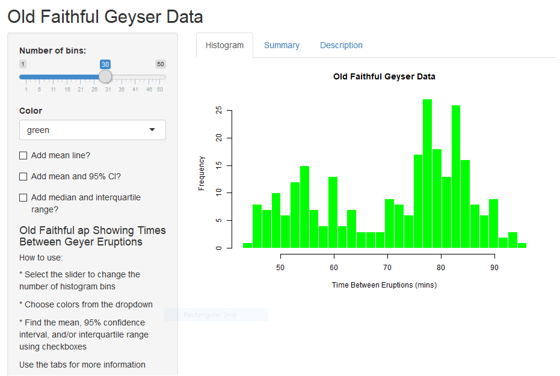

## How to Use

This is handy if you are going to visit the geyser in Yellowstone Park, as the histogram gives an idea of how long to wait between eruptions of water.

- Refine the look of the histogram by providing input. Use the slider to change the bin size, or drop-down to change colors. The histogram will react to your input and redraw itself.
- Check the boxes to see calculations for the average time waiting between eruptions, confidence intervals, or interquartile range (IQR). The IQR gives waiting for about half of the time.
- Select the tabs to see a statistical summary or description with the datasource.

## Code snip

As an example of R-code calculations, code to add the interquartile range looks like this

```
  if(input$addIQR) {  # If the addIQR box is checked...

        # Add vertical lines for the 1Q,Median,3Q
        abline(v = summary(x)[c(2,3,5)],
               lwd = 2,      # Thickness
               lty = 3)      # Dotted line
               }
```

Enjoy and have fun with the ap!

It's located at https://scarr987.shinyapps.io/Geyser1/